# Lab2

Shone George Kutty Renjan

2024-08-29

# Tasks

## Task 1

```r
getwd()
```

```
## [1] "/Users/shonerenjan/OU Course/Applied Statistical Methods /Labs/Lab2"
```

## Tasks 2

```r
epagas=read.csv("EPAGAS.csv")
head(epagas)
```

```
##    MPG
## 1 36.3
## 2 41.0
## 3 36.9
## 4 37.1
## 5 44.9
## 6 36.8
```

## Task 3

Make the object mpg, the number of miles per gallon vector.

```r
mpg=epagas$MPG
head(mpg)
```

```
## [1] 36.3 41.0 36.9 37.1 44.9 36.8
```

Transform the mpg variable to z and verify these results.

```r
z=(mpg -mean(mpg)) /sd(mpg)
head(z)
```

```
## [1] -0.28702628  1.65681163 -0.03887676  0.04383975  3.26978352 -0.08023501
```

```r
print(round(mean(z), 4))
```

```
## [1] 0
```

```r
# Mean of z-score function
print(paste("Mean of z-score = ", round(mean(z), 4)),quote = FALSE)
```

```
## [1] Mean of z-score =  0
```

```r
# Another way to find the mean of z-score
#print(round(mean(z), 4))

# Variance of z function
print(paste("Variance = ", round(var(z), 4)), quote= FALSE)
```

```
## [1] Variance =  1
```

```r
# Another way to get the Variance for z
#sd(z)**2

# Standard Deviation of z function
print(paste("Standard Deviation = ", round(sd(z), 4)), quote= FALSE)
```

```
## [1] Standard Deviation =  1
```

Values of mpg possible outliers.

```r
mpg[abs(z) >= 2 & abs(z) <= 3]
```

```
## [1] 30.0 42.1 31.8
```

Values of mpg that defined as outliers

```r
mpg[abs(z) > 3]
```

```
## [1] 44.9
```

Construct a dotplot with colors, Red=outlier, Blue=possible outlier

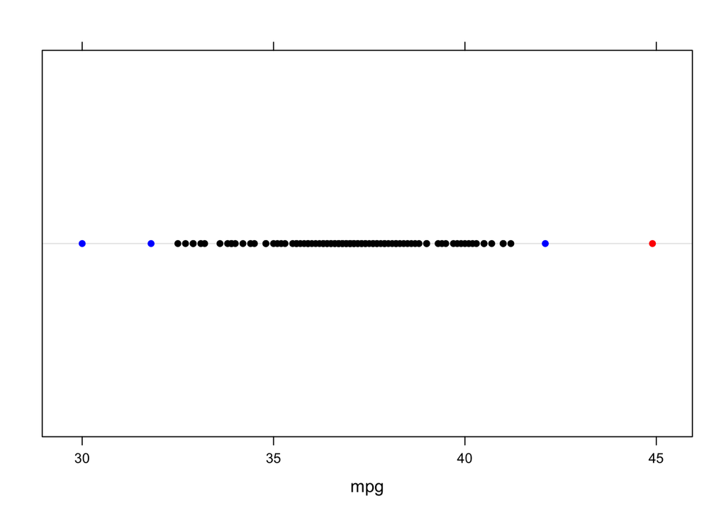

```r
outlier_dotp= ifelse(abs(z)>3, "Red",
                     ifelse(abs(z)>= 2  & abs(z) <= 3, "Blue", "Black"))

library(lattice)
dotplot(mpg, col=outlier_dotp)
```

## Task 4

Make a boxplot of the mpg variable

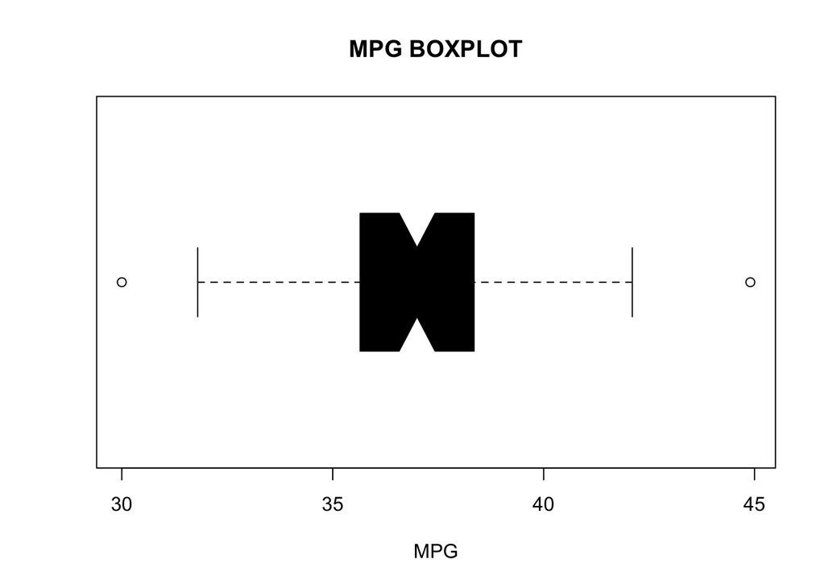

```r
boxplot(mpg, col= "black", notch = TRUE, main ="MPG BOXPLOT", horizontal =TRUE, xlab= "MPG" )
```

### Chebyshev’s theorem

#### 1-(1/k^2)

Proportion of data within 2 standard deviations of the mean of the mpg data o using

```r
k=2
sd=1-(1/k^2)
print(sd)
```

```
## [1] 0.75
```

Proportion within 2 standard deviation of the mean

```r
two_sd =length(mpg[abs(z)<2])
two_sd/length(mpg)
```

```
## [1] 0.96
```

### Chebyshev’s Rule

Chebyshev’s Rule is valid for this data, because it say that at least 75% are between the two deviation of the mean

### Empirical Rule

The Empirical Rule applies to data that is unimodal and roughly symmetrical around the mean, with about 95% of the data falling within two standard deviations. Since data was 96% within this range, your data is close to this rule. To verify, check if the data distribution has a single peak (unimodal) and is symmetrical around the mean.

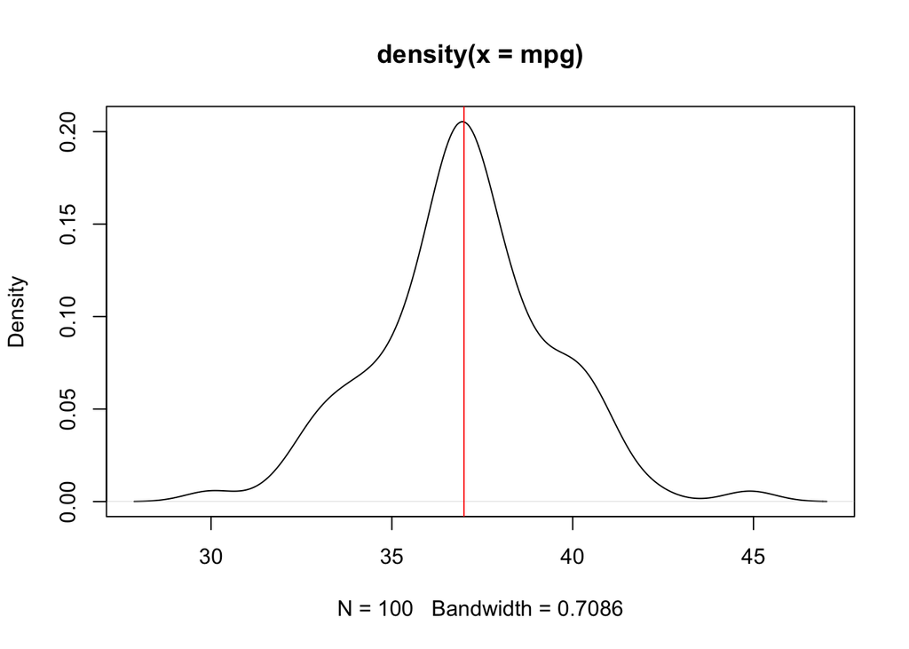

```r
density_mpg = density(mpg)
plot(density_mpg)
abline(v=mean(mpg), col = "red")
```

The Empirical Rule is valid because it is (unimodal) and is symmetrical around the mean.